# Practical Machine Learning for Health Informatic Project

# Overview

This is a health-informatic project. We will be using machine learning to predict the types of barbell lifts. The predictors are data obtained from accelerometers on the belt, forearm, arm, and dumbell of 6 participants.This study will increase our understanding in exercising patterns to improve our health. In this analysis, I have made two major assumptions. First, any predictors that have total number of “NA” or “Empty Values” greater than 10% of the observations are not used. Second, I use K-Nearest Neighbors algorithm for data imputation and model training. K-Nearest Neighbors algorithm is used for the purpose of time saving.

# Experimental Procedure

[1] Load Necessary Libraries

```r
library(ggplot2)
library(lattice)
library(caret)
source("MyFuns.R")
```

[2] Load Traininig and Testing Data

```r
Train.Data <- read.csv("pml-training.csv",header=TRUE)
Test.Data <- read.csv("pml-testing.csv",header=TRUE)
```

[3] Exploratory Data Analysis

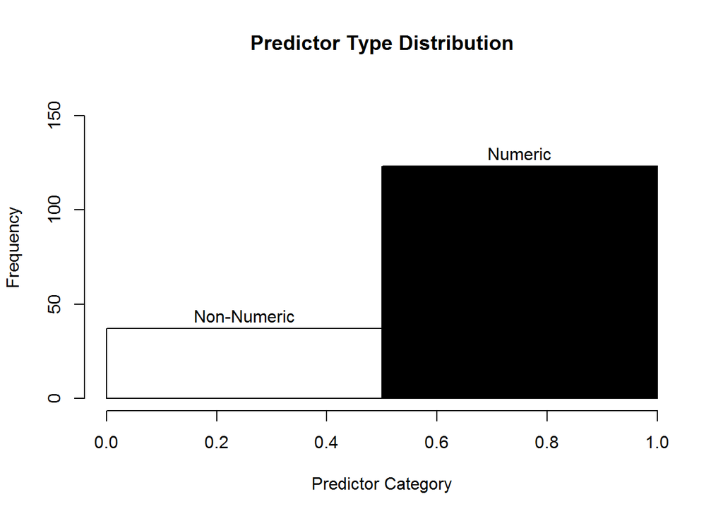

```r
#Looking at the Training data for number of "NAs"  and "Empty values"
index<-sapply(Train.Data,is.numeric)
# Check frequency of numeric and non-numeric predictors
summary(index)
hist(as.numeric(index),2,col = c(0,1),labels = c('Non-Numeric','Numeric'),
     ylim = c(0, 160),xlab='Predictor Category', main="Predictor Type Distribution")
```

[output not shown]

```r
# Check on the statistics of each predictor in Training Data
H=summary(Train.Data)
H=data.frame(H)
H=H[,2:3]
colnames(H)<-c('Predictor','Statistics')
head(H,14)
```

```
##       Predictor      Statistics
## 1             X Min.   :    1
## 2             X 1st Qu.: 4906
## 3             X Median : 9812
## 4             X Mean   : 9812
## 5             X 3rd Qu.:14717
## 6             X Max.   :19622
## 7             X            <NA>
## 8     user_name adelmo  :3892
## 9     user_name carlitos:3112
## 10    user_name charles :3536
## 11    user_name eurico  :3070
## 12    user_name jeremy  :3402
## 13    user_name pedro   :2610
## 14    user_name            <NA>
```

[4] Data Cleaning

```r
# get index to data variable where "NA" or "empty value" is prevalent
ind.RMVars<-DataClean(Train.Data)
# Romove variables that has too many "NA" and "Empty values" and Save it as TemData
TemData<-subset(Train.Data,select=-ind.RMVars)
TemData<-data.frame(TemData,Classes=Train.Data[,dim(Train.Data)[2]])
TemData<-TemData[complete.cases(TemData),]
```

[5] Data Imputation

```r
# Data imputation to fill in "Empty" and "NA"
# (Note: don't use variable "Classes" in Data imputation)
set.seed(13332)
#KNN is used since it is generally less time expensive
DataImputObj <- preProcess(TemData[,!names(TemData) %in% c("Classes")],
                           method = "knnImpute")
Train.MData <- predict(DataImputObj,TemData[,!names(TemData) %in% c("Classes")])
Train.MData$Classes<-TemData$Classes
```

[6] Creating 75% Training Data and 25% Validation Data

```r
# Create TrainD and ValidD
#IS.TrainD -> In-Sample Training Dataset
#IS.ValidD -> In-Sample Validation Dataset
library(caret);library(kernlab)
inTrain<-createDataPartition(y=Train.MData$Classes,
                            p=0.75, list=FALSE)
IS.TrainD<-Train.MData[inTrain,]
IS.ValidD<-Train.MData[-inTrain,]
# Get rid of unnecessary rownames that cause error
row.names(IS.ValidD)<-NULL
```

[7] Obtain Training Model

```r
# Get Training Model with IS.TrainD
library(MASS)
#KNN is used since it is generally less time expensive
modelFit<-train(Classes~., data=IS.TrainD, method="knn",
                preProcess=c("center","scale"))
# Get Validation Results
ValidR<-predict(modelFit,IS.ValidD)
```

```r
# Get Validiation accuracy
ValidR.Acc<-sum(ValidR==IS.ValidD$Classes)/length(IS.ValidD$Classes)
confusionMatrix(ValidR, IS.ValidD$Classes)
```

```
## Confusion Matrix and Statistics
##
##           Reference
## Prediction    A    B    C    D    E
##          A 1373   27    1    0    2
##          B   11  896   12    2    9
##          C    5   24  834   36    3
##          D    3    0    7  764    4
##          E    3    2    1    2  883
##
## Overall Statistics
##
##                Accuracy : 0.9686
##                  95% CI : (0.9633, 0.9733)
##     No Information Rate : 0.2845
##     P-Value [Acc > NIR] : < 2.2e-16
##
##                   Kappa : 0.9603
##  Mcnemar's Test P-Value : 2.928e-06
##
## Statistics by Class:
##
##                      Class: A Class: B Class: C Class: D Class: E
## Sensitivity            0.9842   0.9442   0.9754   0.9502   0.9800
## Specificity            0.9915   0.9914   0.9832   0.9966   0.9980
## Pos Pred Value         0.9786   0.9634   0.9246   0.9820   0.9910
## Neg Pred Value         0.9937   0.9867   0.9948   0.9903   0.9955
## Prevalence             0.2845   0.1935   0.1743   0.1639   0.1837
## Detection Rate         0.2800   0.1827   0.1701   0.1558   0.1801
## Detection Prevalence   0.2861   0.1896   0.1839   0.1586   0.1817
## Balanced Accuracy      0.9878   0.9678   0.9793   0.9734   0.9890
```

[8] Predicting with Test Data [8.1] Test Data Cleaning

```r
# Remove unused variables/predictors from testing dataset
Test.MData<-subset(Test.Data,select=-ind.RMVars)
Test.MData<-data.frame(Test.MData,Classes=Test.Data[,dim(Test.Data)[2]])
Test.MData<-Test.MData[complete.cases(Test.MData),]
```

[8.2] Test Data Imputation

```r
# Imputation with model created from training dataset
OS.TestD <- predict(DataImputObj,Test.MData[,!names(Test.MData)
                                            %in% c("Classes")])
```

[8.3] Test Data Prediction Result

```r
Test.pred<-predict(modelFit,OS.TestD)
```

[9] Generate the Test Data Results as Individual File

```r
source("pml_write_files.R")
pml_write_files(Test.pred)
```

# Result and Discussion

In this analysis, we used K-nearest neighbors for data imputation and model training. Since the number of observations is much greater than the number of predictors, no dimension reduction technique such as PCA is used;chance of overfitting is low. The overfitting problem have also addressed steps in [6] and [7]. The results are generated for the 20 test data in step [9], but I have no groundtruth to compare. However, I expect about 4% out of sample error since our accuracy is about 96% for the validation dataset.

# Appendix

Function #1

```r
DataClean <- function (Data) {
  #[1] Get Data Dimension
  D<-dim(Data)
  #[2.1] Get total "NA" numbers in each column
  Tem<-is.na(Data)
  NA.colsum<-colSums(Tem);
  #[2.2] Removing variables(columns) that its total "NA" values
  #    are greater than 10% of its observations(rows)
  NA.index<- NA.colsum > D[1]*0.1
  # [3.1] Convert each element in the dataframe into a character
  tem<-(sapply(Data,as.character))
  # [3.2] Replace all empty values with "NA"
  tem[tem==""]<-NA
  # [3.3] Convert temporary data into a data.frame
  tem<-data.frame(tem)
  # [3.4] Get total "NA" numbers in each column
  tem<-is.na(tem)
  Empty.colsum<-colSums(tem);
  # [3.5] Removing variables(columns) that its total "NA" values
  #    are greater than 10% of its observations(rows)
  Empty.index<- Empty.colsum > D[1]*0.1
  # [4] Merge NA.ind and Empty.ind
  NA.ind<-as.numeric(which(NA.index==TRUE))
  Empty.ind<-as.numeric(which(Empty.index==TRUE))
  # [5] Get rid of  Index Redundancy
  ind<-unique(c(1:7,NA.ind,Empty.ind,160))
  # [6] Reorder index from small to large
  ind<-sort(ind,decreasing=FALSE)
  return(ind)
}
```

Function #2

```r
pml_write_files = function(x){
  n = length(x)
  for(i in 1:n){
    filename = paste0("problem_id_",i,".txt")
    write.table(x[i],file=filename,quote=FALSE,row.names=FALSE,col.names=FALSE)
  }
}
```